# Climate-readiness of empirical vs. model-based MPs in the US South Atlantic - Black Sea Bass with Overages

Cassidy Peterson

August 2024

# Background

Supplement to Peterson CD. Klibansky N. Vincent MT. Walter III JF. Climate-readiness of fishery management procedures with application to the southeast U.S. Atlantic.

This report contains supplementary materials from a South Atlantic MSE exercise testing the behavior of model-based versus empirical MPs for black sea bass (BSB), vermilion snapper (VS), and red porgy (RP) using the openMSE software (Blue Matter Science).

This section is focused on results for black sea bass *with implementation overages*.

## Abbreviations

- MSE abbreviations
  - MSE - management strategy evaluation
  - OM - operating model
  - MP - management procedure
  - PM - performance metrics
- Case study species
  - VS - vermilion snapper, ‘VS_O’ indicates vermilion snapper with implementation overages
  - BSB - black sea bass, ‘BSB_O’ indicates black sea bass with implementation overages
  - RP- red porgy, ‘RP_O’ indicates red porgy with implementation overages
- Management procedures (MP). Refer to openMSE and [dlmtool](https://dlmtool.openmse.com/reference/index.html) documentation for further details on each MP. Note that all non-SCA MPs are empirical (indicator-based) MPs
  - ZeroC - zero catch MP, used for demonstration purposes only.
  - SCA*x* - statistical catch at age model that occurs every *x* years; may also be specified by a c or p (e.g., SCA5_c) to indicate that catches between assessments are constant (c) or specified by assessment forecast / projections
  - GBtarg - Gt - Geromont and Butterworth target CPUE and catch MP
  - ICI - index confidence interval MP
  - Irat - Ir - Iratio - mean index ratio
  - IT10 - I10 - iterative index target MP
  - Itarg - It - Itarget - incremental index target MP
  - GBslope - Gs - Geromont and Butterworth index slope MP
  - Islope - Is - index slope tracking MP
- Operating model (OM) scenarios
  - Base - base-case OM with no nonstationarity
  - recdev_hi - Mean recruitment deviations in normal space was linearly adjusted to a value twice the size of the historical value from years 11-20 and remained at the shifted value until projection year 50
  - recdev_lo - Mean recruitment deviations in normal space was linearly adjusted to a value half the size of the historical value from years 11-20 and remained at the shifted value until projection year 50
  - age0M_hi - A shift in age-0 natural mortality simulated by linearly increasing age-0 M from the historical value to twice the historical value from years 11-20 and remaining at the higher value until projection year 50
  - age0M_lo - A shift in age-0 natural mortality simulated by linearly decreasing age-0 M from the historical value to half the historical value from years 11-20 and remaining at the lower value until projection year 50
  - recns - Base case recruitment deviations are multiplied by a random walk vector with a mean of 1 and standard deviation of 5 (using random_walk function in bamExtras version 0.0.1 R package)
  - epiM - A multiplier greater than 1 is applied to historical natural mortality (M) in 10% of years; multiplier was defined as $1+lognormal(\mu = 0$,$\sigma = 0.2$) with a maximum value of 3 for red porgy or 4 for black sea bass and vermilion snapper
  - uobs_hi - The coefficient of variation (CV) of the survey index was linearly increased from the value from the last year of the historical period to twice that level over years 11-20 and remaining at the higher value until projection year 50
  - uobs_lo - The CV of the survey index was linearly decreased from the value from the last year of the historical period to half that level over years 11-20 and remaining at the higher value until projection year 50
- Performance metrics (PMs)
  - $dSSB_{0}$ - dynamic spawning stock biomass that would occur under no fishing pressure
  - $F_{MSY}$ - the rate of fishing mortality ($F$) that would produce MSY
  - $SSB_{MSY}$ - SSB that would produce MSY if fished at $F_{MSY}$
  - $SSB_{y}$ - SSB in the year $y$
  - SSBratio - The ratio of SSB to dynamic SSB that would be achieved in the absence of fishing ($dSSB_{0}$) calculated annually
  - t10SSBratio - Mean terminal 10 years of SSBratio; SSBratio calculated annually over the final 10 years of the projection period and averaged across years 40-50
  - Fratio - The ratio of realized fishing mortality ($F$) to the rate that would produce MSY ($F_{MSY}$) calculated annually
  - PNOF - Probability of not overfishing, calculated as the proportion of years that $F/F_{MSY}$ exceeds 1 for the 50-year projection period of each projection iteration
  - P100 - Proportion of years in the final 10 years of the simulation period (years 40-50) in which SSB>SSBMSY for each projection iteration
  - cyield - Cumulative relative yield, where relative yield is calculated as realized yield relative to OM-defined MSY (i.e., if yield = MSY, then relative yield = 1 for that year) summed across all 50 projected years
  - AAVY - Annual average variability in yield, calculated as the average change in yield from year-to-year across all years of the projection period: $AAVY= \Sigma_{t=0}^{t=50} sqrt( (((yield_{t}-yield_{t-1}) / (yield_{t-1} ))^{2}) )$

# Black Sea Bass with Implementation Overages Results

## Median Trajectory Plots

Below plots demonstrate median trajectories across 250 iterations per OM and MP scenario. Note y-axis limits.

### Median SSBratio trajectory

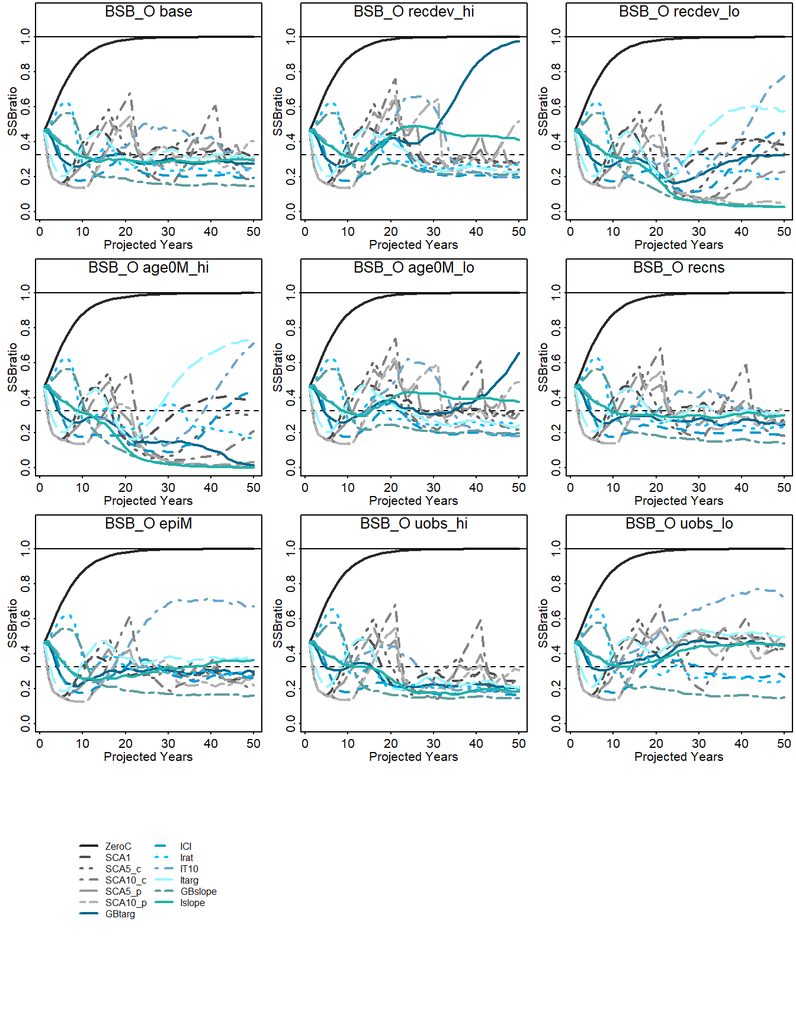

Figure 1. Median SSBratio ($SSB / dSSB_{0}$) trajectories for each MP in each OM.

### Median $SSB / SSB_{MSY}$ trajectory

Note that changes to recruitment deviations are not reflected in MSY-based reference points.

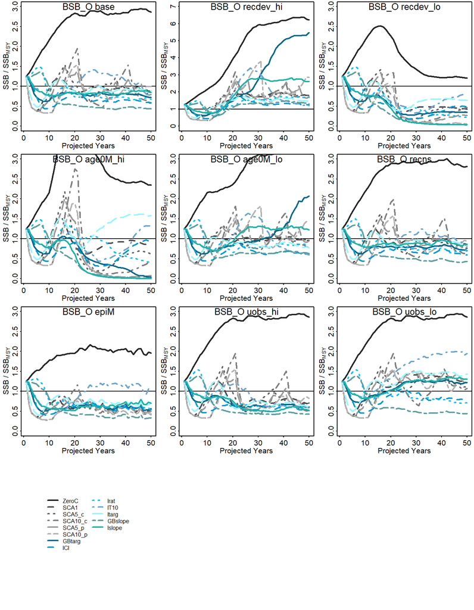

Figure 2. Median $SSB / static SSB_{MSY}$ trajectories for each MP in each OM.

### Median catch trajectory

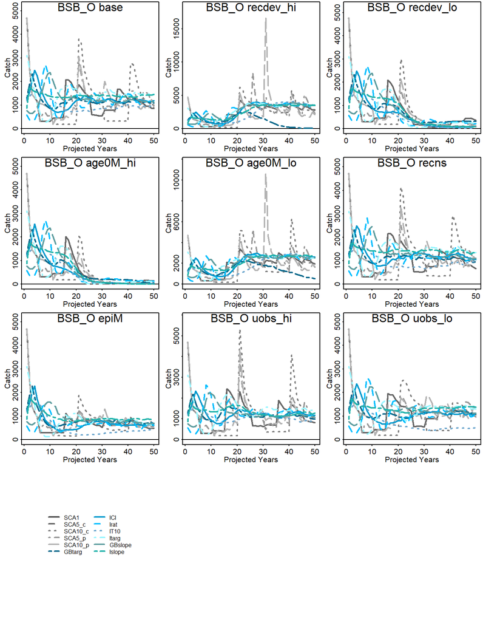

Figure 3. Median catch trajectories for each MP in each OM.

### Median SSBratio trajectory with 90% CIs

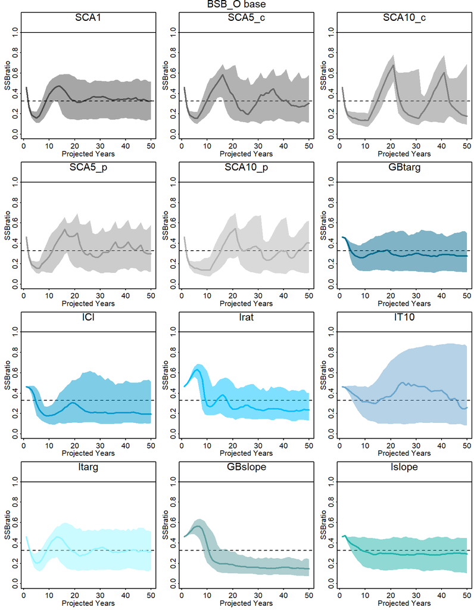

Figure 4. Median SSBratio ($SSB / dSSB_{0}$) trajectories for each MP with 90% confidence intervals. Each MP is plotted in a single coordinate for each OM scenario for simplicity.

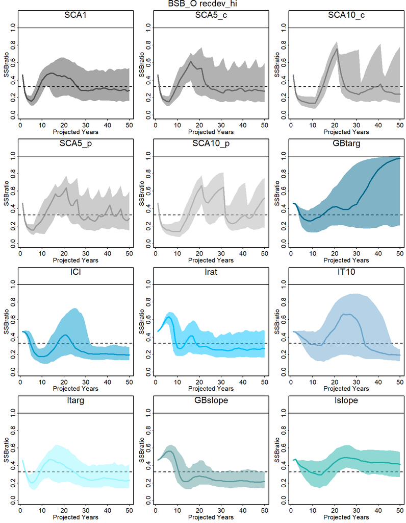

Figure 4. Median SSBratio ($SSB / dSSB_{0}$) trajectories for each MP with 90% confidence intervals. Each MP is plotted in a single coordinate for each OM scenario for simplicity.

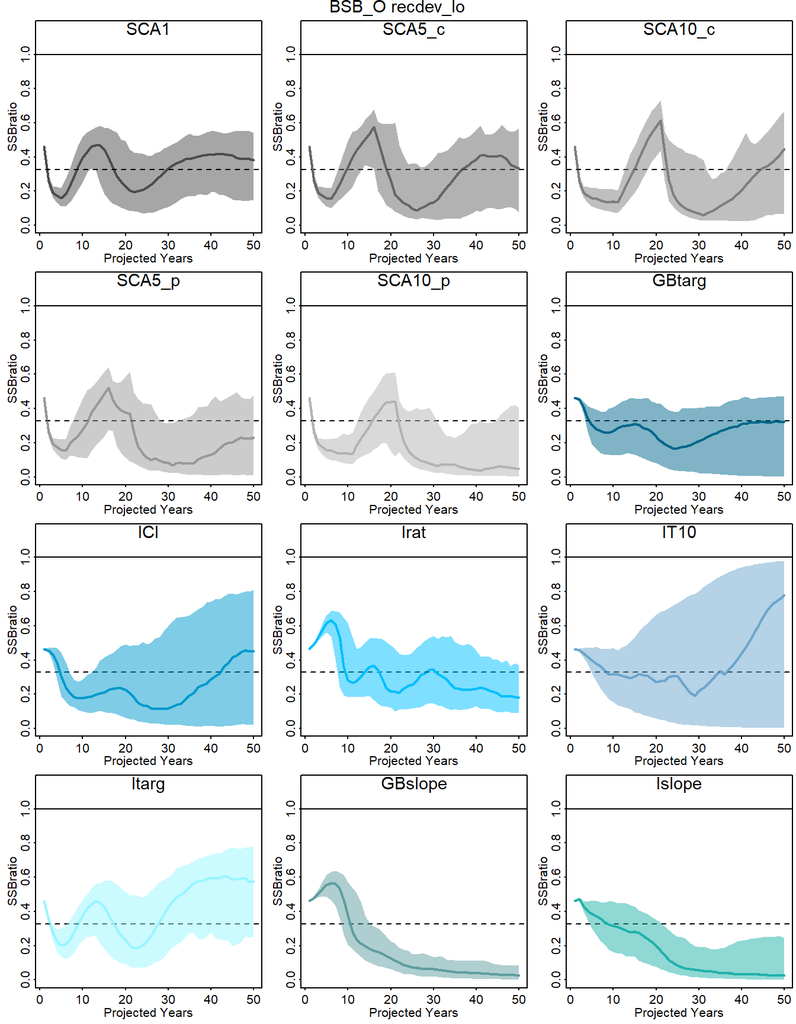

Figure 4. Median SSBratio ($SSB / dSSB_{0}$) trajectories for each MP with 90% confidence intervals. Each MP is plotted in a single coordinate for each OM scenario for simplicity.

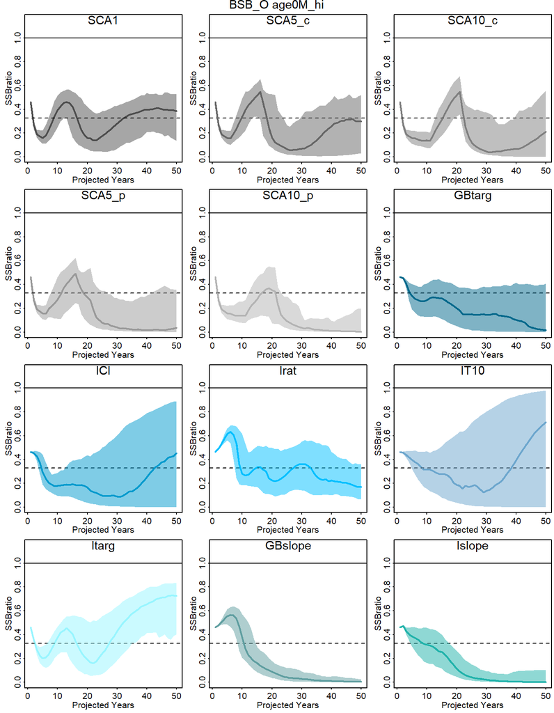

Figure 4. Median SSBratio ($SSB / dSSB_{0}$) trajectories for each MP with 90% confidence intervals. Each MP is plotted in a single coordinate for each OM scenario for simplicity.

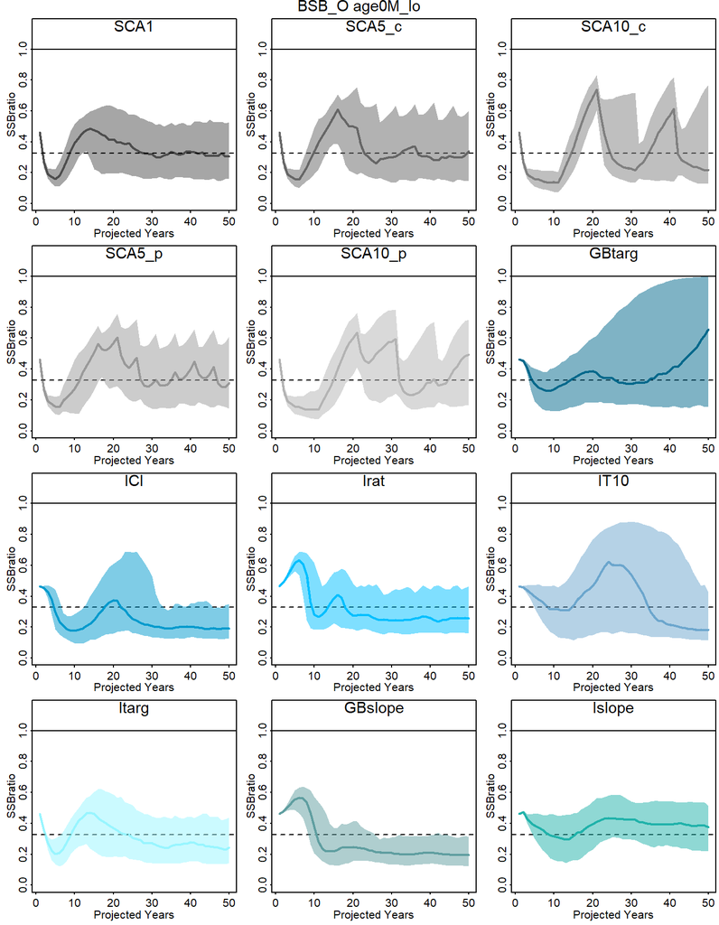

Figure 4. Median SSBratio ($SSB / dSSB_{0}$) trajectories for each MP with 90% confidence intervals. Each MP is plotted in a single coordinate for each OM scenario for simplicity.

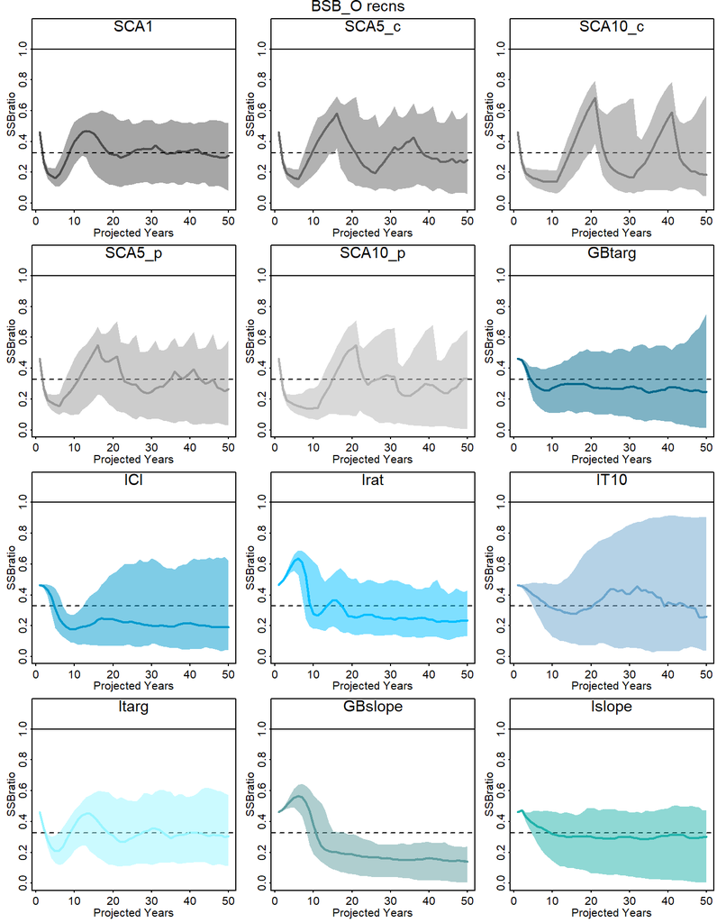

Figure 4. Median SSBratio ($SSB / dSSB_{0}$) trajectories for each MP with 90% confidence intervals. Each MP is plotted in a single coordinate for each OM scenario for simplicity.

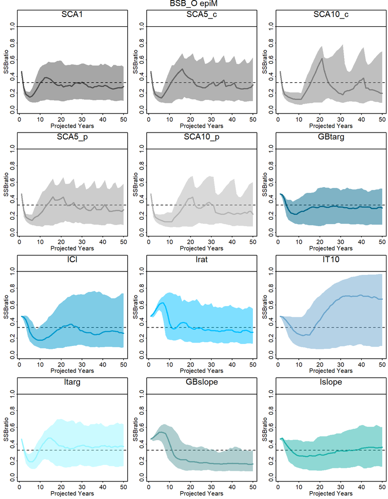

Figure 4. Median SSBratio ($SSB / dSSB_{0}$) trajectories for each MP with 90% confidence intervals. Each MP is plotted in a single coordinate for each OM scenario for simplicity.

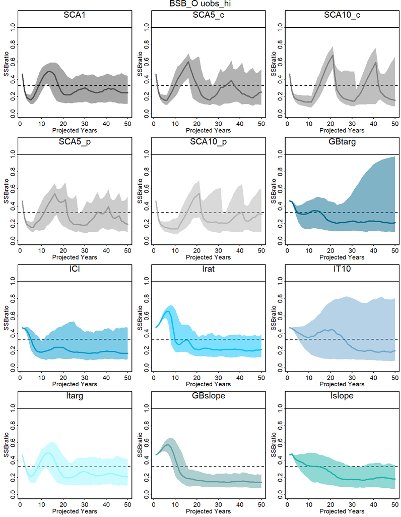

Figure 4. Median SSBratio ($SSB / dSSB_{0}$) trajectories for each MP with 90% confidence intervals. Each MP is plotted in a single coordinate for each OM scenario for simplicity.

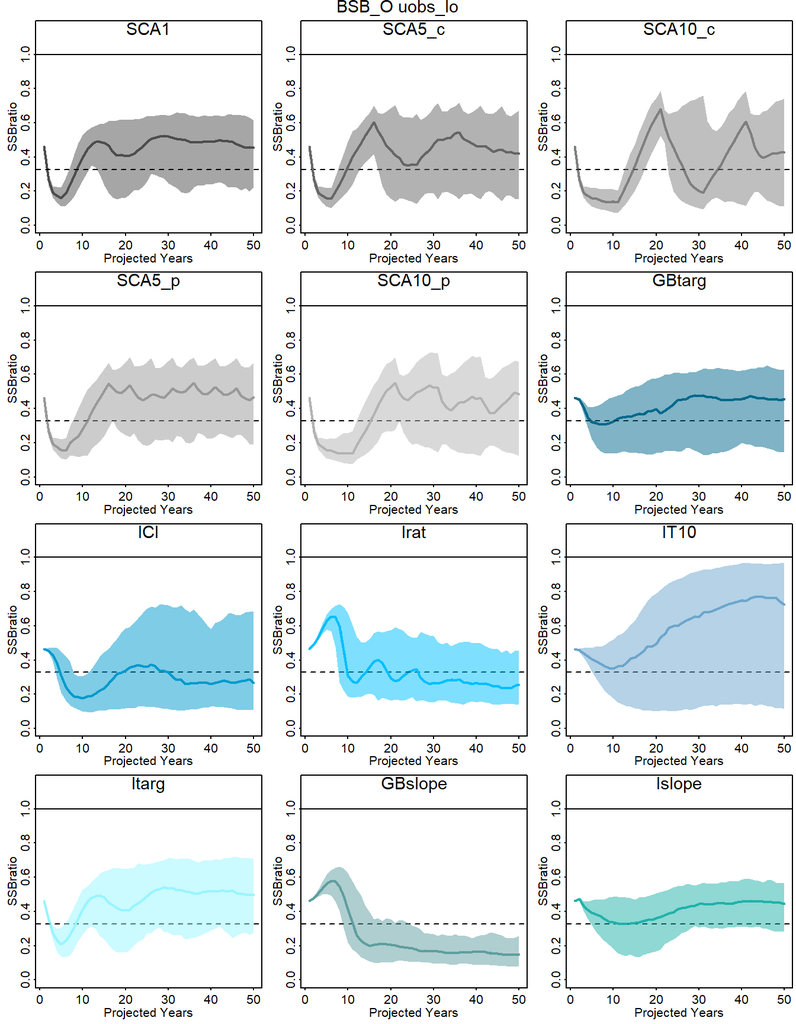

Figure 4. Median SSBratio ($SSB / dSSB_{0}$) trajectories for each MP with 90% confidence intervals. Each MP is plotted in a single coordinate for each OM scenario for simplicity.

## Violin plots

Below plots demonstrate distribution of performance metrics across 250 iterations per OM and MP scenario. Note y-axis limits.

### Biomass

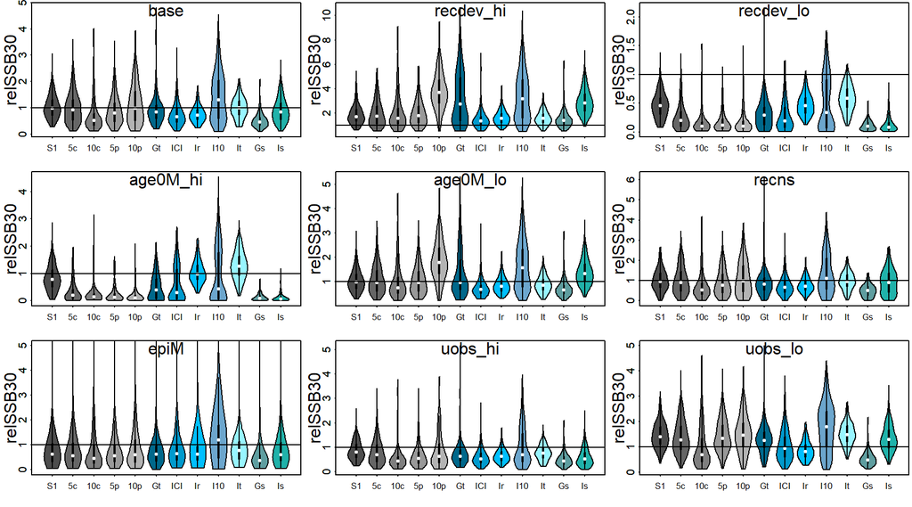

Figure 5. Relative $SSB/SSB_{MSY}$ at year 30 by MP for each OM.

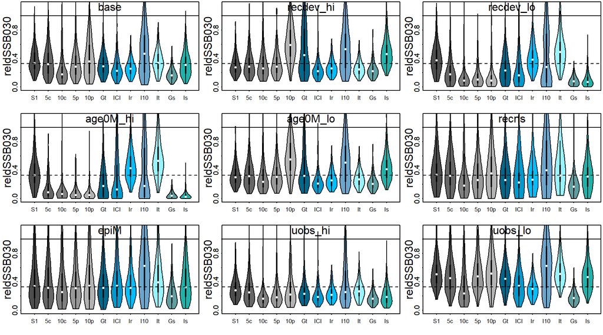

Figure 6. Relative SSBratio ($SSB / dSSB_{0}$) at year 30 (reldSSB030) by MP for each OM. Horizontal reference line is indicative of $SSB_{MSY}/SSB_{0}$ calculated at the OM conditioning step; note that this reference value may change over the projection period as population dynamics change, which is not considered for this illustration.

### Fishing mortality

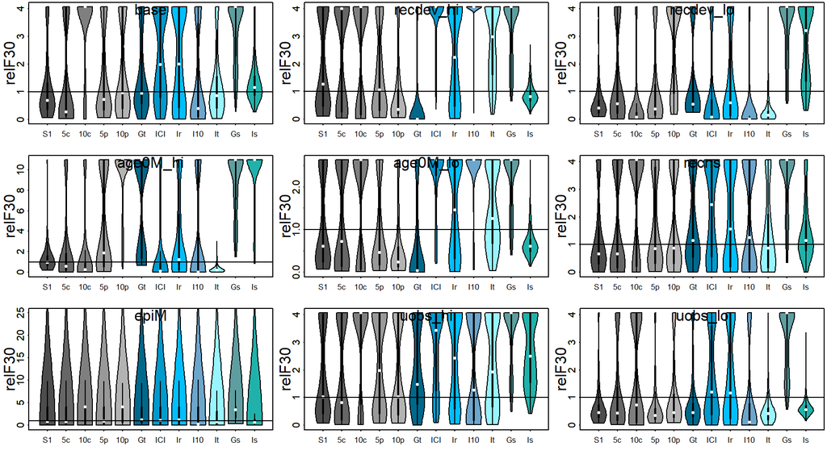

Figure 7. Relative $F/F{MSY}$ at year 30 by MP for each OM.

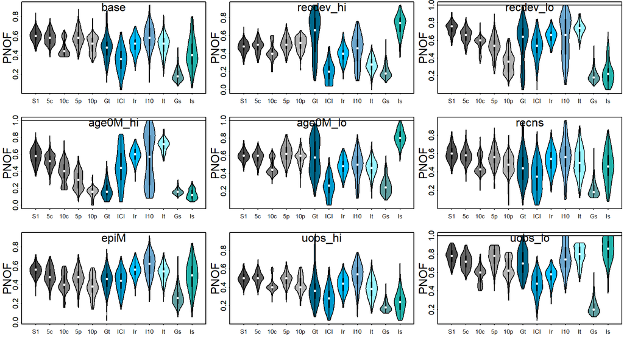

Figure 8. Probability of not overfishing (PNOF) across the 50-year projection period by MP for each OM.

### Yield

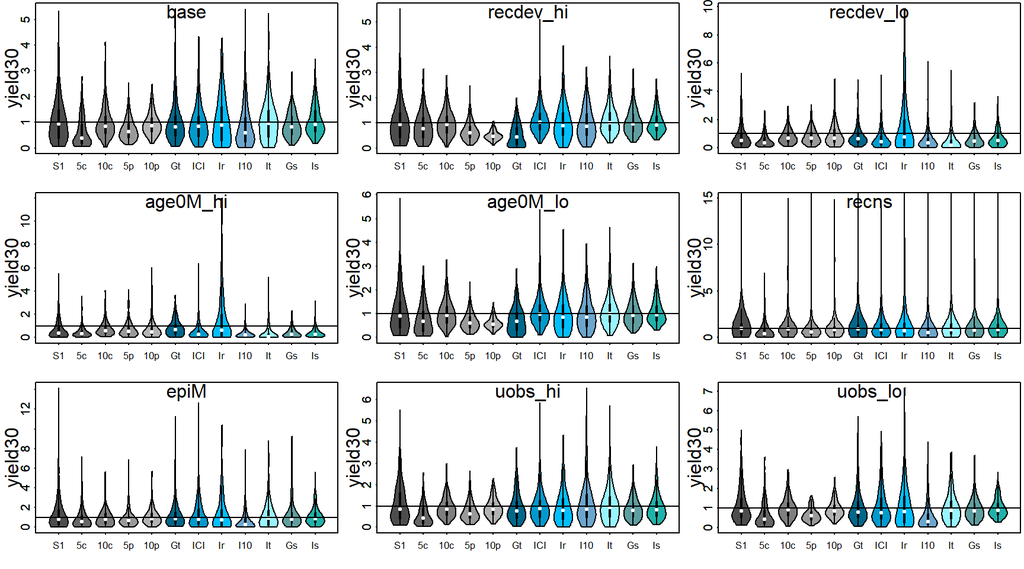

Figure 9. Relative yield (yield / MSY) at projection year 30 by MP for each OM.

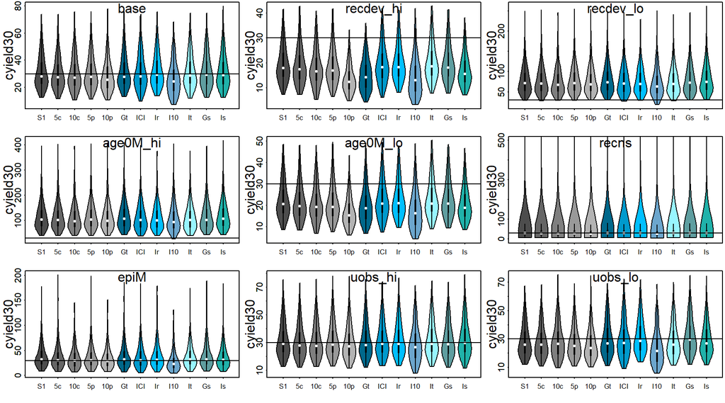

Figure 10. Cumulative relative yield (yield / MSY) at projection year 30 by MP for each OM.

## Cumulative Violin Plots (Across all OMs)

Below plots demonstrate distribution of performance metrics across all iterations, OMs, and MPs. Note y-axis limits.

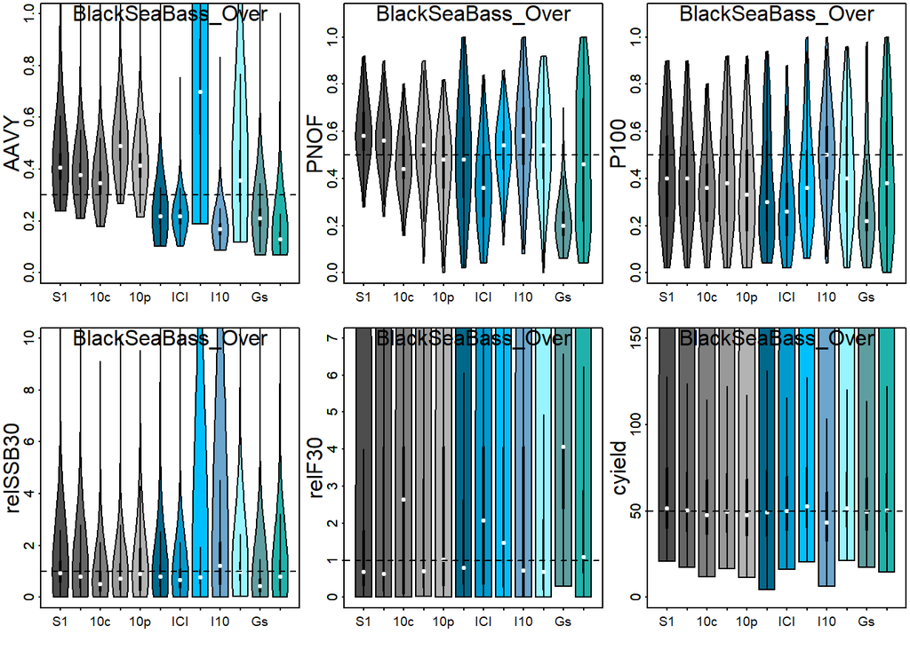

Figure 11. MP performance across OMs